# Piecewise Regression with Negative Binomial Type I Error on Real Data using `brms` Custom Family

Michael Gilchrist

Created: 2023-02-28; Compiled: Mon Mar 27 13:55:35 2023

# Goal

- Fit two piece negative binomial type 1 formulation to data
- From 2023-02-28 version of `nbinom_type1.R`

> Negative Binomial distribution parameterized by mean (mu) and overdispersion parameter (theta). This parameterization is referred to as NEGBIN type I (Cameron and Trivedi, 1998) as cited by https://doi.org/10.1080/03610926.2018.1563164 ## `x ~ nbinom_type1(mu, theta)`, where `E(x) = mu, Var(x) = (theta + 1) mu` This should not be confused with the mu and shape parameterization of nbinom in R or the ‘alternative’ NB (`neg_binomial_2_...`) in stan Note using disp instead of theta because using theta gives the error > Error: Currently ‘dirichlet’ is the only valid prior for simplex parameters. See help(set_prior) for more details. when trying to fit the model.

## Recap

- Code initially based on work in
- `../2022-12-20_rstan_two.piece.qpoisson.with.real.data/rstan_two.piece_fit.various.models.to.real.data.Rmd`
- That model behaved well but, because I was writing stan code directly, I hadn’t been able to group data by `male`
- Since then, I’ve created a `brms` `custom_family()` which uses the Type 1 formulation of the NB.

## Insights

### Reconciling use of `s0` with `x0`

In an effort to udnerstand hte difference between earlier work with `rstan` and this current work with `brms`, it seems that the key difference is both approaches use an implicit flat prior and, thus, result in inconsistency.

To understand this, I want to transform the flat prior on `s0` into the corresponding prior on `x0`. In order to do so, I am following`Proposition B` on p. 60 of Rice (1995) stats book.

Specifically, if `s0 = 1/(xmax - x0)` such that `y = y0 * s0 * (xmax - max(x, x0))`

# Set up

## Install libraries

```r
# install packages user might not have by replacing FALSE with TRUE

## load libraries
library(stats)
library(MASS) # provides negative binomial fitting:  glm.nb
library(ggplot2)
library(ggpubr)
library(grid)
library(gridExtra)
library(GGally)
library(broom)
library(tidyverse)
library(viridisLite)
library(cmdstanr)
library(rstan)
options(mc.cores = (parallel::detectCores()-2))
rstan_options(auto_write = TRUE)
library(brms)
library(loo)


## options(ggplot2.continuous.colour="viridis",
##        ggplot2.discrete.colour="viridis",
##        ggplot2.scale_fill_discrete = scale_fill_viridis_d,
##        ggplot2.scale_fill_continuous = scale_fill_viridis_c)

library(reshape2)
library(lme4)
library(latex2exp)
```

## Source family

```r
source("../../../custom-brms-families/families/nbinom_type1.R")
```

## Load Data

```r
sapply(file.path("input", dir("input")),
       load, verbose = TRUE, envir = .GlobalEnv)
```

```
## Loading objects:
##   data_ind
## Loading objects:
##   summary_stats
## Loading objects:
##   stats_ind
```

```
##          input/data_ind.Rda input/obs_summary_stats.Rda
##                  "data_ind"             "summary_stats"
##         input/stats_ind.Rda
##                 "stats_ind"
```

```r
head(stats_ind)
```

```
## # A tibble: 6 × 9
##   male  round n_obs total_round mean_round sd_round cv_round total  mean
##   <fct> <dbl> <int>       <int>      <dbl>    <dbl>    <dbl> <int> <dbl>
## 1 T234      1    13         203       40.6     32.0    0.787   601  46.2
## 2 T235      1    13         882      176.     132.     0.748  2333 179.
## 3 T236      1    13         758      152.      46.0    0.303  2095 161.
## 4 T243      1    13         438       87.6     76.4    0.872  1861 143.
## 5 T244      1    13         270       54       14.7    0.272   993  76.4
## 6 T246      1     5         253       50.6     54.6    1.08    253  50.6
```

```r
names(stats_ind)
```

```
## [1] "male"        "round"       "n_obs"       "total_round" "mean_round"
## [6] "sd_round"    "cv_round"    "total"       "mean"
```

```r
head(data_ind)
```

```
## # A tibble: 6 × 11
##   male  index motif_…¹ temp_…²  temp round trial…³ date  counter y0_si…⁴ phi_ind
##   <chr> <int>    <int>   <dbl> <dbl> <dbl>   <dbl> <chr> <chr>     <dbl>   <dbl>
## 1 T234      1        0      42  43.0     1       1 02/0… RAS        46.2    12.3
## 2 T234      1       30      44  44.5     1       2 02/0… RAS        46.2    12.3
## 3 T234      1       34      27  27.2     1       3 02/0… RAS        46.2    12.3
## 4 T234      1       87      40  41.1     1       4 02/0… RAS        46.2    12.3
## 5 T234      1       52      35  36.1     1       5 02/1… RAS        46.2    12.3
## 6 T234      1       32      40  39.5     2       1 04/2… KIM        46.2    12.3
## # … with abbreviated variable names ¹motif_count, ²temp_target, ³trial_round,
## #   ⁴y0_simple_est
```

```r
names(data_ind)
```

```
##  [1] "male"          "index"         "motif_count"   "temp_target"
##  [5] "temp"          "round"         "trial_round"   "date"
##  [9] "counter"       "y0_simple_est" "phi_ind"
```

# Prior Work

### Fit with Stan: Separate: `y0`, and `x0`, Pooled $\theta$

- Based on results in `../2022-12-20_rstan_two.piece.qpoisson.with.real.data/rstan_two.piece_fit.various.models.to.real.data.Rmd`
- Histograms of `x0[]` suggest following groupings
1. `c(2, 4, 6, 8, 11)`
2. `c(1, 3, 5, 7, 10)`
3. `9` is ambiguous.
- NOTE: I’m not 100% sure these index values are the same as the ones we are using here!

```r
x0_groups_2_base <- list(low = c(2, 4, 6, 8, 11), high = c(1, 3, 5, 7, 10)) ## Does not include bird with index 9

x0_groups_2a <- x0_groups_2b <- x0_groups_2_base

x0_groups_2a$low <- c(x0_groups_2_base$low, 9) %>% sort()
x0_groups_2b$high <- c(x0_groups_2_base$high, 9) %>% sort()
```

# Fit Models

- Code derived from `../2023-02-23_brms_nb_focus.on.x0.fittings/nb_focus.on.estimating.x0.fittings.Rmd`

## Set up functions, parameters, and results tibble

```r
data_stan <- data_ind %>% rename(y = motif_count, x = temp) %>%
  mutate(male = factor(male))

xmax <- 46
stan_two_piece_x0_func <- paste0(" real  two_piece(real x, real x0, real y0) {
 real xmax = ", xmax, "; ## paste in value for xmax\n
 return(y0 * (xmax - fmax(x0, x))/(xmax - x0));
 } ")

stan_two_piece_s0_func <- paste0(" real  two_piece(real x, real s0, real y0) {
 real xmax = ", xmax, "; ## paste in value for xmax\n
 real x0 = xmax - 1/s0;
 real y = y0 * s0 * (xmax - fmax(x, x0));
 return(y);
 } ")


models <- c("x0_piecewise") #, "s0_piecewise") #, "asymptotic")
sampling_dists <- c("nbinom_type1") ##, "com_poisson") ## lognormal doesn't work since the counts can be 0.
flags_x0 <- c("uniform_1",
              "groups_1", ## this doesn't work with x0_Intercept prior, suggests error in priors
              #"groups_2a",
              #"groups_2b",
              "individual")

flags_y0 <- switch(1,
                   c("individual"),
                   c("uniform_1", "groups_1", "individual")
                   )

disp_prior_list <- switch(2,
                          c(0.125), # This works well and is sane
                          c(0.0675, 0.125, 0.25), # used in exploring model behavior
                          c("flat") # not used
                          )

N <- length(data)

fit_tbl <- crossing(model = models,
                    sampling_dist = sampling_dists,
                    x0_flag = flags_x0, y0_flag = flags_y0,
                    disp_prior = disp_prior_list,
                    desc = "NA_character",
                    y0_group_list = list(NA), #tbl_tmp, #list(NA),
                    x0_group_list = list(NA),
                    fit = list(NA),
                    llik = list(NA),
                    r_eff = list(NA),
                    loo = list(NA)
                    )
```

### Run fits

```r
run_fits = TRUE
force_load = FALSE  #reload fit_tbl even if it already exits
save_fits = TRUE

infile_tbl <- file.path(output_dir, paste0("fit_tbl_", Sys.Date(), ".Rda"))
outfile_tbl <- file.path(output_dir, paste0("fit_tbl_", Sys.Date(), ".Rda"))


sampling = "nbinom_type1"

flags_x0_used <- c("uniform_1", "individual") # "groups_1"
flags_y0_used <- c("individual")
disp_prior_used <- disp_prior_list
models_used <- c("x0_piecewise") #, "x0_piecewise")

fit_index <- 0;

for(model in models_used) {
    switch(model,
#           "piecewise" = {stan_func <- stan_two_piece_x0_func},
           "x0_piecewise" = {
             stan_func <- stan_two_piece_x0_func
             warmup <- 3000 #floor(3/4 * iter)
             iter <- warmup + 3000
             adapt_delta <- 0.8
             thin <- 4
           },
           "s0_piecewise" = {
             stan_func <- stan_two_piece_s0_func
             warmup <- 15000
             iter <- warmup + 10000
             thin <- 4
             adapt_delta <- 0.95
           }
           )

    print(model)
    print(stan_func)

    for(x0_flag in flags_x0_used) {
      s0_flag <- x0_flag ## define synonym

      for(y0_flag in flags_y0_used) {

        print_get_prior <- TRUE ## reset value
        print_prior_summary <- TRUE

      for(disp_prior in disp_prior_used) {

          ## used when loading fits
          fit_index <- fit_index + 1;
          ## Set up variables for saving model and fit

          desc_short <- paste0("x0 " , x0_flag, "; y0 ", y0_flag, "; disp prior ", disp_prior)
          desc <- paste0(sampling, "; ", model, "; ", desc_short)

          filename_desc <- gsub("_", "-", desc) %>%
              gsub("; ", "_", .) %>%
              gsub(" ", "-", .)

          curr_row <- which(fit_tbl$model == model &
                            fit_tbl$sampling_dist == sampling &
                            fit_tbl$x0_flag == x0_flag &
                            fit_tbl$y0_flag == y0_flag &
                            fit_tbl$disp_prior == disp_prior)
        fit_tbl[ curr_row, ]$desc <- desc

        print(desc)

        if(run_fits) {


            print("Fitting Models")
              switch(sampling,
                     "nbinom_type1"= {
                         family <- nbinom_type1(link = "identity", link_disp = "identity")
                         adapt_delta <- adapt_delta #0.95 ## will decreasing value increase ESS? Seems like it
                         iter <- iter
                         warmup <- warmup
                         thin <- thin
                         n_cores <- 4 ## set to 1 if getting errors from stan in order to see relevant message.
                         n_chains <- n_cores
                         nbinom_type1_vars <-
                             stanvar(scode = paste(
                                         stan_func,
                                         stan_nbinom_type1, sep = "\n"),
                                     block = "functions")
                     }
         )

          ## Refresh data in case x0_group or y0_group are all set to 1
          data <- data_stan

          print("Set flags based on fitted model structure")
          if(x0_flag %in% c("uniform_1", "groups_1")) data <- mutate(data, x0_group = 1)
          if(y0_flag %in% c("uniform_1", "groups_1")) data <-mutate(data, y0_group = 1)
          if(x0_flag %in% c("individual")) data <- mutate(data, x0_group = male)
          if(y0_flag %in% c("individual")) data <- mutate(data, y0_group = male)

          ## Note we need to put a tibble into a list because row updates, even if doing
          ## just one cell, require a list format.
          ## Haven't defined "y0_group" or "x0_group" variables
          if(FALSE) {
            fit_tbl[[curr_row, "x0_group_list"]] <- list(unique(data[, c("male", "x0_group")]))
            fit_tbl[[curr_row, "y0_group_list"]] <- list(unique(data[, c("male", "y0_group")]))
          }

          print("Define parameter formulas")
          x0_form <- switch(x0_flag,
                            uniform_1 = formula(x0 ~ 1),
                            uniform_2 = formula(x0 ~ x0_group),
                            # Don't include x0_group info which is determined by the data set
                            groups_1 = formula(x0 ~ 0 + Intercept + (1|male)),
                            groups_2 = formula(x0 ~ (1|male) + x0_group),
                            individual = formula(x0 ~ 0 + male) ## Do not use 1 + male!
                            )
          s0_form <- formula(deparse(x0_form) %>% gsub("x0 ", "s0 ", .))


          y0_form <- switch(y0_flag,
                            uniform_1 = formula(y0 ~ 1),
                            uniform_2 = formula(y0 ~ 1 + y0_group),
                            groups_1 = formula(y0 ~ 1 + (1| male)),
                            groups_2 = formula(y0 ~ 1 + (1| male) + y0_group),
                            individual = formula(y0 ~ 0 + male)
                            ## `-1 + ` gives me the error:
                            ## Warning in parallel::mclapply(1:chains, FUN = callFun, mc.preschedule = FALSE,  :
                            ##  4 function calls resulted in an error
                            ## Error in FUN(X[[i]], ...) :
                            ##  trying to get slot "mode" from an object (class "try-error") that is not an S4 object
                            ## should I use `0 +` or `-1 +` ?
                            )

          threshold_form <- switch(model,
                                     x0_piecewise = x0_form,
                                     s0_piecewise = s0_form
                                     )

          nlform <- switch(model,
                           x0_piecewise = bf(y ~ two_piece(x, x0, y0), nl = TRUE),
                           s0_piecewise = bf(y ~ two_piece(x, s0, y0), nl = TRUE)
                           ) +
            threshold_form +
            y0_form

          if(print_get_prior) {
            print(get_prior(nlform,
                            data = data,
                            family = family
                            ))
            print_get_prior <- FALSE # will get reset
          }
```

```r
          print("Define priors")
          ## Strangely reducing the parameter of the exponential results in a higher estimate of 'disp' and increasing the parameter decreases the estimates of 'disp'
          disp_priors <- set_prior(switch(1,
                               paste0("exponential(", disp_prior, ")"), ## Similar to one used in earlier work with rstan
                               normal(15, 2.8), ## Based on analysis of non-noisy 40C song data
                               normal(6, 2.8), ## Based on analysis of non-noisy 40C song data
                               exponential(0.667), ## 0.625 = 1/16  "
                               paste0("constant(", disp_prior, ")") ## Making disp a constant oesn't really help.
                              ), class = "disp", lb = 0, ub = 20)

          x0_prior <- switch(x0_flag,
                              uniform_1 = NULL,
                              uniform_2 = NULL,
                              # Don't include x0_group info which is determined by the data set
                              groups_1 = prior(student_t(3, 0, 66.7), lb = 0, ub = 3, class = "sd", nlpar = "x0"),
                              groups_2 = NULL,
                              individual = NULL
                              )

          x0_priors <- prior(uniform(25, 45), lb = 25, ub = 45, nlpar = "x0") + x0_prior

          s0_prior <- switch(s0_flag,
                              uniform_1 = NULL,
                              uniform_2 = NULL,
                              # Don't include x0_group info which is determined by the data set
                              groups_1 = prior(student_t(3, 0, 66.7), lb = 0, ub = 0.3333, class = "sd", nlpar = "s0"),
                              groups_2 = NULL,
                              individual = NULL
                              )

          s0_priors <- s0_prior +
            prior(uniform(0.02, 1), lb = 0.02, ub = 1, nlpar = "s0")

          y0_priors <- switch(y0_flag,
                              uniform_1 = prior(normal(150, 100), nlpar = "y0"),
                              uniform_2 = NULL,
                              groups_1 = NULL,
                              groups_2 = NULL,
                              individual = switch(1,
                                                  prior(normal(150, 1000), nlpar = "y0", lb = 10, ub = 1000), ## save value as with origina rstan fits
                                                  prior(uniform(10, 1000), nlpar = "y0", lb = 10, ub = 1000)
                                                  )
                              )

          threshold_priors <- switch(model,
                                     x0_piecewise = x0_priors,
                                     s0_piecewise = s0_priors
                                     )

          prior <- switch(sampling,
                          "nbinom_type1" = {
                            disp_priors +
                              threshold_priors + y0_priors
                          })


          save_model <-paste0(paste0(output_dir, "/stan/brms", model, sampling, x0_flag, y0_flag, disp_prior, sep = "_"), ".stan")
          #make_stancode( .... save_model = save.model)
          fit <- brm(nlform,
                     data = data,
                     ## `link` refers to the mapping of the expectation of the distribution: log, sqrt, identity, softplus
                     ## link_shape corresponds to `phi` of `stan`'s
                     ## Negbinomial_2
                     ## Defining `phi = mu/theta` creates a quasipoisson
                     ## distribution with overdispersion parameter (1 +theta)
                     family = family, #negbinomial(link = "identity", link_shape = "identity"),
                     prior = prior,
                     stanvars = nbinom_type1_vars,
                     iter = iter,
                     warmup = warmup,
                     thin = thin,
                     silent = ifelse(interactive(), 1, 2), # 0, 1, or 2. 1 is default
                     control = list(adapt_delta = adapt_delta,
                                    max_treedepth = 12
                                    ##model_name = desc ## Incorrect way to set this.
                                    ),
                     ## Only print out sampling progress if in interactive mode
                     refresh = ifelse(interactive(),max(iter/5, 1), 0),
                     chains = n_chains,
                     cores = n_cores,
                     save_model = save_model
                     )

          # print(desc)
          # print("Prior Information")
          # print(prior_summary(fit))
          # print("Fit Information")
          # print(fit)

          #fit_exp <- expose_functions(fit) , vectorize = TRUE)
          #fit_cr <- add_criterion(fit_exp, c("loo", "waic"))
          fit_tbl[[curr_row, "fit"]] <- list(fit)
          ## Print current warnings
          warnings(summary)
          ## Clear warnings()

          ## End if(run_fit)
        } else {
          print("Working with Pre-existing Fits")


          ## Try to assign from local memory.
          fit <- fit_tbl[[curr_row, "fit"]][[1]]

          ## Load fit if undefined or desired
          if(is.na(list(fit)) | force_load) {
            print("Loading Models")
            #if(fit_index ==1)
            load(file = infile_tbl)
            fit <- fit_tbl[[curr_row, "fit"]][[1]]
          }
        }

        if(is.na(list(fit))) {
          warning(paste0("model fit ", desc, "does not exist.\n Skipping."))
        } else {
          ## Print and plot results, regardless of which fits one uses
          print(desc)
          if(print_prior_summary) {
            print("Fit Prior Information")
            print(prior_summary(fit)) # %>% filter(nlpar!="y0"))
            print_prior_summary <- TRUE
          }
          print("Fit Information")
          print(summary(fit)) #, pars = "x0*"))          %>% filter(nlpar!="y0"))
          fit_stan <- fit$fit
          #clean up variable names
          fit_stan_rename <-
            fit_stan %>%
            setNames(gsub("b_", "", names(.)) %>%
                       gsub("(x0|s0|y0)_male(T[0-9]{3})", "\\2_\\1", .) %>%
                       gsub("__", "_", .) %>%
                       gsub("r_male_(x0|s0|y0)\\[(T[0-9]{3}),Intercept\\]", "\\2_\\1_r", .) %>%
                       gsub("\\.", " ", .))
```

```
## [1] "x0_piecewise"
## [1] " real  two_piece(real x, real x0, real y0) {\n real xmax = 46; ## paste in value for xmax\n\n return(y0 * (xmax - fmax(x0, x))/(xmax - x0));\n } "
## [1] "nbinom_type1; x0_piecewise; x0 uniform_1; y0 individual; disp prior 0.0675"
## [1] "Fitting Models"
## [1] "Set flags based on fitted model structure"
## [1] "Define parameter formulas"
##   prior class      coef group resp dpar nlpar lb   ub       source
##  (flat)  disp                                  0 <NA>      default
##  (flat)     b                              x0              default
##  (flat)     b Intercept                    x0         (vectorized)
##  (flat)     b                              y0              default
##  (flat)     b  maleT234                    y0         (vectorized)
##  (flat)     b  maleT235                    y0         (vectorized)
##  (flat)     b  maleT236                    y0         (vectorized)
##  (flat)     b  maleT237                    y0         (vectorized)
##  (flat)     b  maleT243                    y0         (vectorized)
##  (flat)     b  maleT244                    y0         (vectorized)
##  (flat)     b  maleT246                    y0         (vectorized)
##  (flat)     b  maleT247                    y0         (vectorized)
##  (flat)     b  maleT257                    y0         (vectorized)
##  (flat)     b  maleT258                    y0         (vectorized)
##  (flat)     b  maleT260                    y0         (vectorized)
## [1] "Define priors"
## [1] "nbinom_type1; x0_piecewise; x0 uniform_1; y0 individual; disp prior 0.0675"
## [1] "Fit Prior Information"
##                prior class      coef group resp dpar nlpar lb   ub       source
##      uniform(25, 45)     b                              x0 25   45         user
##      uniform(25, 45)     b Intercept                    x0 25   45 (vectorized)
##    normal(150, 1000)     b                              y0 10 1000         user
##    normal(150, 1000)     b  maleT234                    y0 10 1000 (vectorized)
##    normal(150, 1000)     b  maleT235                    y0 10 1000 (vectorized)
##    normal(150, 1000)     b  maleT236                    y0 10 1000 (vectorized)
##    normal(150, 1000)     b  maleT237                    y0 10 1000 (vectorized)
##    normal(150, 1000)     b  maleT243                    y0 10 1000 (vectorized)
##    normal(150, 1000)     b  maleT244                    y0 10 1000 (vectorized)
##    normal(150, 1000)     b  maleT246                    y0 10 1000 (vectorized)
##    normal(150, 1000)     b  maleT247                    y0 10 1000 (vectorized)
##    normal(150, 1000)     b  maleT257                    y0 10 1000 (vectorized)
##    normal(150, 1000)     b  maleT258                    y0 10 1000 (vectorized)
##    normal(150, 1000)     b  maleT260                    y0 10 1000 (vectorized)
```

[output cut: 18 more lines]

```
## y0_maleT243    122.30      8.28   106.68   138.51 1.00     2839     2605
## y0_maleT244     81.65      6.33    69.75    94.66 1.00     3163     2913
## y0_maleT246     29.80      6.88    17.45    44.66 1.00     2920     2911
## y0_maleT247    112.25      7.51    97.66   127.14 1.00     3025     2833
## y0_maleT257    236.91     18.09   203.20   273.40 1.00     2975     3073
## y0_maleT258     33.27      6.39    21.61    46.41 1.00     3109     2946
## y0_maleT260     90.83     11.06    69.12   113.23 1.00     2736     2858
##
## Family Specific Parameters:
##      Estimate Est.Error l-95% CI u-95% CI Rhat Bulk_ESS Tail_ESS
## disp     6.01      0.49     5.12     7.02 1.00     3032     2819
##
## Draws were sampled using sampling(NUTS). For each parameter, Bulk_ESS
## and Tail_ESS are effective sample size measures, and Rhat is the potential
## scale reduction factor on split chains (at convergence, Rhat = 1).
```

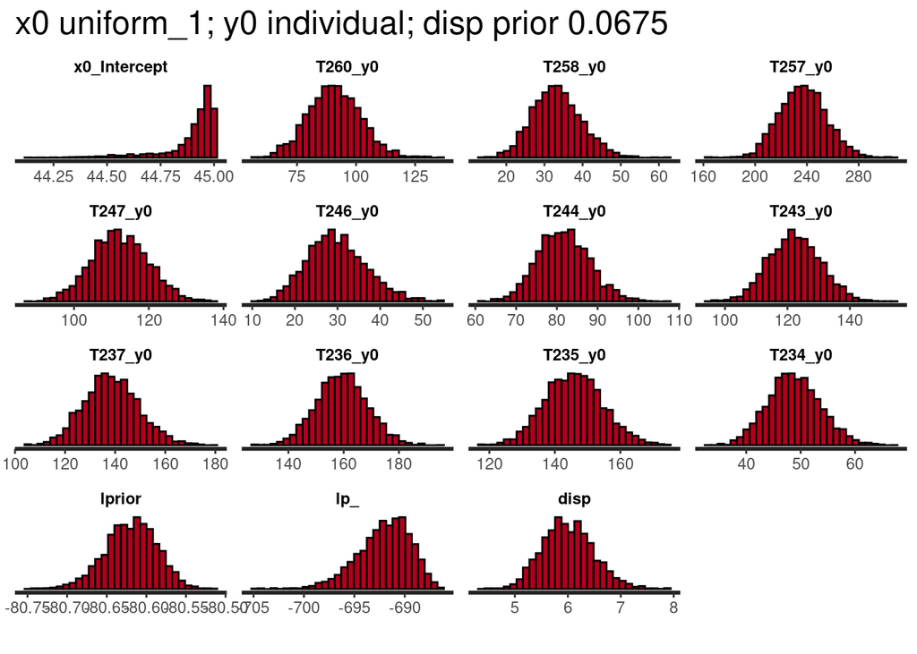

```
## [1] "nbinom_type1; x0_piecewise; x0 uniform_1; y0 individual; disp prior 0.125"
## [1] "Fitting Models"
## [1] "Set flags based on fitted model structure"
## [1] "Define parameter formulas"
## [1] "Define priors"
## [1] "nbinom_type1; x0_piecewise; x0 uniform_1; y0 individual; disp prior 0.125"
## [1] "Fit Prior Information"
##               prior class      coef group resp dpar nlpar lb   ub       source
##     uniform(25, 45)     b                              x0 25   45         user
##     uniform(25, 45)     b Intercept                    x0 25   45 (vectorized)
##   normal(150, 1000)     b                              y0 10 1000         user
##   normal(150, 1000)     b  maleT234                    y0 10 1000 (vectorized)
##   normal(150, 1000)     b  maleT235                    y0 10 1000 (vectorized)
##   normal(150, 1000)     b  maleT236                    y0 10 1000 (vectorized)
##   normal(150, 1000)     b  maleT237                    y0 10 1000 (vectorized)
##   normal(150, 1000)     b  maleT243                    y0 10 1000 (vectorized)
##   normal(150, 1000)     b  maleT244                    y0 10 1000 (vectorized)
##   normal(150, 1000)     b  maleT246                    y0 10 1000 (vectorized)
##   normal(150, 1000)     b  maleT247                    y0 10 1000 (vectorized)
##   normal(150, 1000)     b  maleT257                    y0 10 1000 (vectorized)
##   normal(150, 1000)     b  maleT258                    y0 10 1000 (vectorized)
##   normal(150, 1000)     b  maleT260                    y0 10 1000 (vectorized)
##  exponential(0.125)  disp                                  0   20         user
## [1] "Fit Information"
##  Family: nbinom_type1
##   Links: mu = identity; disp = identity
## Formula: y ~ two_piece(x, x0, y0)
##          x0 ~ 1
##          y0 ~ 0 + male
##    Data: data (Number of observations: 107)
##   Draws: 4 chains, each with iter = 6000; warmup = 3000; thin = 4;
##          total post-warmup draws = 3000
##
## Population-Level Effects:
##              Estimate Est.Error l-95% CI u-95% CI Rhat Bulk_ESS Tail_ESS
## x0_Intercept    44.90      0.12    44.51    45.00 1.00     2664     2619
## y0_maleT234     48.94      4.91    39.48    58.92 1.00     3092     2791
## y0_maleT235    145.54      8.87   128.46   163.64 1.00     3202     2994
## y0_maleT236    159.51      8.96   142.36   177.58 1.00     2955     2951
## y0_maleT237    138.42     10.85   117.48   159.68 1.00     2970     2835
## y0_maleT243    122.21      8.16   106.38   138.57 1.00     2672     2950
## y0_maleT244     81.53      6.19    69.87    93.91 1.00     2994     3030
## y0_maleT246     29.71      6.97    17.04    44.74 1.00     3017     2616
## y0_maleT247    112.72      7.23    98.67   127.42 1.00     2791     2951
## y0_maleT257    236.81     18.05   202.68   273.14 1.00     3045     2867
## y0_maleT258     33.06      6.31    21.63    46.06 1.00     2742     2671
## y0_maleT260     90.98     10.69    71.45   112.38 1.00     2965     2873
##
## Family Specific Parameters:
##      Estimate Est.Error l-95% CI u-95% CI Rhat Bulk_ESS Tail_ESS
## disp     6.01      0.49     5.09     7.01 1.00     3032     2788
##
## Draws were sampled using sampling(NUTS). For each parameter, Bulk_ESS
## and Tail_ESS are effective sample size measures, and Rhat is the potential
## scale reduction factor on split chains (at convergence, Rhat = 1).
```

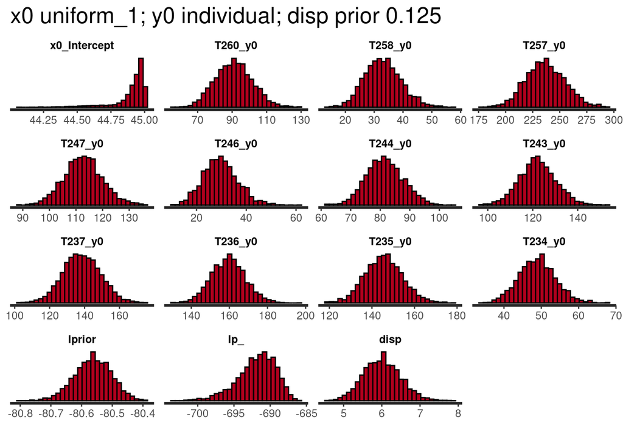

```
## [1] "nbinom_type1; x0_piecewise; x0 uniform_1; y0 individual; disp prior 0.25"
## [1] "Fitting Models"
## [1] "Set flags based on fitted model structure"
## [1] "Define parameter formulas"
## [1] "Define priors"
## [1] "nbinom_type1; x0_piecewise; x0 uniform_1; y0 individual; disp prior 0.25"
## [1] "Fit Prior Information"
##              prior class      coef group resp dpar nlpar lb   ub       source
##    uniform(25, 45)     b                              x0 25   45         user
##    uniform(25, 45)     b Intercept                    x0 25   45 (vectorized)
##  normal(150, 1000)     b                              y0 10 1000         user
##  normal(150, 1000)     b  maleT234                    y0 10 1000 (vectorized)
##  normal(150, 1000)     b  maleT235                    y0 10 1000 (vectorized)
##  normal(150, 1000)     b  maleT236                    y0 10 1000 (vectorized)
##  normal(150, 1000)     b  maleT237                    y0 10 1000 (vectorized)
##  normal(150, 1000)     b  maleT243                    y0 10 1000 (vectorized)
##  normal(150, 1000)     b  maleT244                    y0 10 1000 (vectorized)
##  normal(150, 1000)     b  maleT246                    y0 10 1000 (vectorized)
##  normal(150, 1000)     b  maleT247                    y0 10 1000 (vectorized)
##  normal(150, 1000)     b  maleT257                    y0 10 1000 (vectorized)
##  normal(150, 1000)     b  maleT258                    y0 10 1000 (vectorized)
##  normal(150, 1000)     b  maleT260                    y0 10 1000 (vectorized)
##  exponential(0.25)  disp                                  0   20         user
## [1] "Fit Information"
##  Family: nbinom_type1
##   Links: mu = identity; disp = identity
## Formula: y ~ two_piece(x, x0, y0)
##          x0 ~ 1
##          y0 ~ 0 + male
##    Data: data (Number of observations: 107)
##   Draws: 4 chains, each with iter = 6000; warmup = 3000; thin = 4;
##          total post-warmup draws = 3000
##
## Population-Level Effects:
##              Estimate Est.Error l-95% CI u-95% CI Rhat Bulk_ESS Tail_ESS
## x0_Intercept    44.90      0.13    44.51    45.00 1.00     2728     2783
## y0_maleT234     48.75      4.87    39.38    58.86 1.00     2810     2914
## y0_maleT235    145.34      8.86   128.58   163.06 1.00     2748     2835
## y0_maleT236    159.37      9.32   140.77   178.42 1.00     3012     2853
## y0_maleT237    138.53     10.89   117.68   160.24 1.00     2996     2665
## y0_maleT243    122.48      8.27   106.75   138.88 1.00     2893     2948
## y0_maleT244     81.56      6.37    69.61    94.46 1.00     2825     2789
## y0_maleT246     29.51      6.74    17.26    43.74 1.00     2867     2951
## y0_maleT247    112.44      7.41    98.38   126.84 1.00     3242     2740
## y0_maleT257    237.50     17.54   203.09   273.09 1.00     2967     2874
## y0_maleT258     33.25      6.43    21.57    46.24 1.00     3045     2908
## y0_maleT260     90.68     10.72    70.36   112.42 1.00     2998     2436
##
## Family Specific Parameters:
##      Estimate Est.Error l-95% CI u-95% CI Rhat Bulk_ESS Tail_ESS
## disp     5.96      0.47     5.11     6.96 1.00     2866     2751
##
## Draws were sampled using sampling(NUTS). For each parameter, Bulk_ESS
## and Tail_ESS are effective sample size measures, and Rhat is the potential
## scale reduction factor on split chains (at convergence, Rhat = 1).
```

```
## [1] "nbinom_type1; x0_piecewise; x0 individual; y0 individual; disp prior 0.0675"
## [1] "Fitting Models"
## [1] "Set flags based on fitted model structure"
## [1] "Define parameter formulas"
##   prior class     coef group resp dpar nlpar lb   ub       source
##  (flat)  disp                                 0 <NA>      default
##  (flat)     b                             x0              default
##  (flat)     b maleT234                    x0         (vectorized)
##  (flat)     b maleT235                    x0         (vectorized)
##  (flat)     b maleT236                    x0         (vectorized)
##  (flat)     b maleT237                    x0         (vectorized)
##  (flat)     b maleT243                    x0         (vectorized)
##  (flat)     b maleT244                    x0         (vectorized)
##  (flat)     b maleT246                    x0         (vectorized)
##  (flat)     b maleT247                    x0         (vectorized)
##  (flat)     b maleT257                    x0         (vectorized)
##  (flat)     b maleT258                    x0         (vectorized)
##  (flat)     b maleT260                    x0         (vectorized)
##  (flat)     b                             y0              default
##  (flat)     b maleT234                    y0         (vectorized)
##  (flat)     b maleT235                    y0         (vectorized)
##  (flat)     b maleT236                    y0         (vectorized)
##  (flat)     b maleT237                    y0         (vectorized)
##  (flat)     b maleT243                    y0         (vectorized)
##  (flat)     b maleT244                    y0         (vectorized)
##  (flat)     b maleT246                    y0         (vectorized)
##  (flat)     b maleT247                    y0         (vectorized)
##  (flat)     b maleT257                    y0         (vectorized)
##  (flat)     b maleT258                    y0         (vectorized)
##  (flat)     b maleT260                    y0         (vectorized)
## [1] "Define priors"
```

```
## [1] "nbinom_type1; x0_piecewise; x0 individual; y0 individual; disp prior 0.0675"
## [1] "Fit Prior Information"
##                prior class     coef group resp dpar nlpar lb   ub       source
##      uniform(25, 45)     b                             x0 25   45         user
##      uniform(25, 45)     b maleT234                    x0 25   45 (vectorized)
##      uniform(25, 45)     b maleT235                    x0 25   45 (vectorized)
##      uniform(25, 45)     b maleT236                    x0 25   45 (vectorized)
##      uniform(25, 45)     b maleT237                    x0 25   45 (vectorized)
##      uniform(25, 45)     b maleT243                    x0 25   45 (vectorized)
##      uniform(25, 45)     b maleT244                    x0 25   45 (vectorized)
##      uniform(25, 45)     b maleT246                    x0 25   45 (vectorized)
##      uniform(25, 45)     b maleT247                    x0 25   45 (vectorized)
##      uniform(25, 45)     b maleT257                    x0 25   45 (vectorized)
##      uniform(25, 45)     b maleT258                    x0 25   45 (vectorized)
##      uniform(25, 45)     b maleT260                    x0 25   45 (vectorized)
##    normal(150, 1000)     b                             y0 10 1000         user
##    normal(150, 1000)     b maleT234                    y0 10 1000 (vectorized)
##    normal(150, 1000)     b maleT235                    y0 10 1000 (vectorized)
##    normal(150, 1000)     b maleT236                    y0 10 1000 (vectorized)
##    normal(150, 1000)     b maleT237                    y0 10 1000 (vectorized)
##    normal(150, 1000)     b maleT243                    y0 10 1000 (vectorized)
##    normal(150, 1000)     b maleT244                    y0 10 1000 (vectorized)
##    normal(150, 1000)     b maleT246                    y0 10 1000 (vectorized)
##    normal(150, 1000)     b maleT247                    y0 10 1000 (vectorized)
##    normal(150, 1000)     b maleT257                    y0 10 1000 (vectorized)
##    normal(150, 1000)     b maleT258                    y0 10 1000 (vectorized)
##    normal(150, 1000)     b maleT260                    y0 10 1000 (vectorized)
##  exponential(0.0675)  disp                                 0   20         user
## [1] "Fit Information"
```

[figure not shown]

```
##  Family: nbinom_type1
##   Links: mu = identity; disp = identity
## Formula: y ~ two_piece(x, x0, y0)
##          x0 ~ 0 + male
##          y0 ~ 0 + male
##    Data: data (Number of observations: 107)
##   Draws: 4 chains, each with iter = 6000; warmup = 3000; thin = 4;
##          total post-warmup draws = 3000
##
## Population-Level Effects:
##             Estimate Est.Error l-95% CI u-95% CI Rhat Bulk_ESS Tail_ESS
## x0_maleT234    40.35      1.48    36.55    42.39 1.00     2668     2189
## x0_maleT235    40.49      7.73    25.36    45.00 1.53        7       31
## x0_maleT236    39.33      3.27    35.76    44.98 1.53        7       29
## x0_maleT237    38.64      2.38    34.53    43.95 1.00     1682     1702
## x0_maleT243    43.56      0.58    42.17    44.42 1.00     2895     2629
## x0_maleT244    44.13      0.84    41.82    44.97 1.00     3133     2720
## x0_maleT246    44.48      0.77    42.23    44.99 1.00     2723     2868
## x0_maleT247    43.53      0.88    41.43    44.81 1.00     2827     2757
## x0_maleT257    43.53      0.88    41.79    44.92 1.00     2602     2419
## x0_maleT258    37.11      3.22    27.74    42.11 1.00     2377     1518
## x0_maleT260    42.74      1.34    40.37    44.91 1.00     2587     2591
## y0_maleT234    59.36      7.55    46.86    76.13 1.00     2629     2691
## y0_maleT235   188.22     75.55   130.22   351.90 1.53        7       31
## y0_maleT236   183.52     19.37   149.27   220.08 1.42        8       30
## y0_maleT237   160.75     24.04   126.91   212.70 1.00     2165     1708
## y0_maleT243   133.84      9.27   116.17   152.15 1.00     2920     2690
## y0_maleT244    82.44      6.59    70.27    95.88 1.00     2756     2630
## y0_maleT246    29.04      6.76    17.01    43.26 1.00     3069     2625
## y0_maleT247   116.96      8.25   101.79   134.36 1.00     2978     2851
## y0_maleT257   238.39     17.57   205.93   274.49 1.00     2782     2723
## y0_maleT258    54.61     12.70    34.34    83.99 1.00     2545     2326
## y0_maleT260    91.08     10.83    70.57   113.05 1.00     2994     2904
##
## Family Specific Parameters:
##      Estimate Est.Error l-95% CI u-95% CI Rhat Bulk_ESS Tail_ESS
## disp     5.91      0.50     5.00     6.97 1.07       40      662
##
## Draws were sampled using sampling(NUTS). For each parameter, Bulk_ESS
## and Tail_ESS are effective sample size measures, and Rhat is the potential
## scale reduction factor on split chains (at convergence, Rhat = 1).
```

```
## [1] "nbinom_type1; x0_piecewise; x0 individual; y0 individual; disp prior 0.125"
## [1] "Fitting Models"
## [1] "Set flags based on fitted model structure"
## [1] "Define parameter formulas"
## [1] "Define priors"
```

```
## [1] "nbinom_type1; x0_piecewise; x0 individual; y0 individual; disp prior 0.125"
## [1] "Fit Prior Information"
##               prior class     coef group resp dpar nlpar lb   ub       source
##     uniform(25, 45)     b                             x0 25   45         user
##     uniform(25, 45)     b maleT234                    x0 25   45 (vectorized)
##     uniform(25, 45)     b maleT235                    x0 25   45 (vectorized)
##     uniform(25, 45)     b maleT236                    x0 25   45 (vectorized)
##     uniform(25, 45)     b maleT237                    x0 25   45 (vectorized)
##     uniform(25, 45)     b maleT243                    x0 25   45 (vectorized)
##     uniform(25, 45)     b maleT244                    x0 25   45 (vectorized)
##     uniform(25, 45)     b maleT246                    x0 25   45 (vectorized)
##     uniform(25, 45)     b maleT247                    x0 25   45 (vectorized)
##     uniform(25, 45)     b maleT257                    x0 25   45 (vectorized)
##     uniform(25, 45)     b maleT258                    x0 25   45 (vectorized)
##     uniform(25, 45)     b maleT260                    x0 25   45 (vectorized)
##   normal(150, 1000)     b                             y0 10 1000         user
##   normal(150, 1000)     b maleT234                    y0 10 1000 (vectorized)
##   normal(150, 1000)     b maleT235                    y0 10 1000 (vectorized)
##   normal(150, 1000)     b maleT236                    y0 10 1000 (vectorized)
##   normal(150, 1000)     b maleT237                    y0 10 1000 (vectorized)
##   normal(150, 1000)     b maleT243                    y0 10 1000 (vectorized)
##   normal(150, 1000)     b maleT244                    y0 10 1000 (vectorized)
##   normal(150, 1000)     b maleT246                    y0 10 1000 (vectorized)
##   normal(150, 1000)     b maleT247                    y0 10 1000 (vectorized)
##   normal(150, 1000)     b maleT257                    y0 10 1000 (vectorized)
##   normal(150, 1000)     b maleT258                    y0 10 1000 (vectorized)
##   normal(150, 1000)     b maleT260                    y0 10 1000 (vectorized)
##  exponential(0.125)  disp                                 0   20         user
## [1] "Fit Information"
```

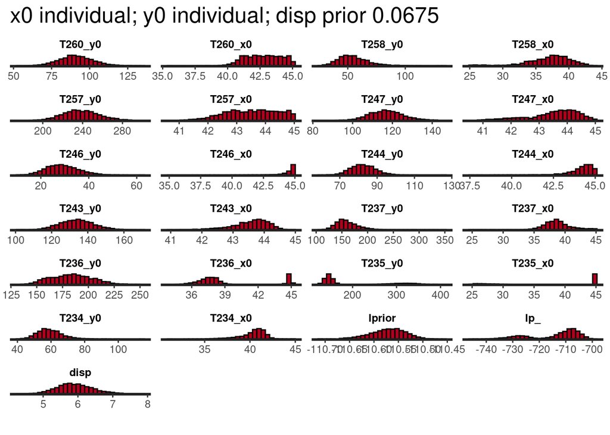

```
##  Family: nbinom_type1
##   Links: mu = identity; disp = identity
## Formula: y ~ two_piece(x, x0, y0)
##          x0 ~ 0 + male
##          y0 ~ 0 + male
##    Data: data (Number of observations: 107)
##   Draws: 4 chains, each with iter = 6000; warmup = 3000; thin = 4;
##          total post-warmup draws = 3000
##
## Population-Level Effects:
##             Estimate Est.Error l-95% CI u-95% CI Rhat Bulk_ESS Tail_ESS
## x0_maleT234    40.39      1.44    36.78    42.33 1.00     2502     1696
## x0_maleT235    40.53      7.67    25.35    45.00 1.53        7       36
## x0_maleT236    41.19      3.71    35.99    44.99 1.73        6      158
## x0_maleT237    38.73      2.30    34.89    44.14 1.00     2160     2057
## x0_maleT243    43.53      0.57    42.21    44.43 1.00     2714     2414
## x0_maleT244    44.12      0.85    41.87    44.97 1.00     2557     2592
## x0_maleT246    44.48      0.86    42.24    44.99 1.00     2586     2620
## x0_maleT247    43.50      0.87    41.45    44.77 1.00     2646     2822
## x0_maleT257    43.58      0.88    41.89    44.93 1.00     2421     2399
## x0_maleT258    37.31      3.11    29.07    42.18 1.00     2853     2261
## x0_maleT260    42.71      1.35    40.15    44.88 1.00     2891     2694
## y0_maleT234    59.08      7.48    46.69    76.08 1.00     2548     2384
## y0_maleT235   187.31     74.83   129.90   353.00 1.53        7       33
## y0_maleT236   175.23     20.57   145.22   218.09 1.61        7      118
## y0_maleT237   160.41     22.83   128.48   207.64 1.00     2463     2278
## y0_maleT243   133.91      9.05   116.73   152.01 1.00     3049     2586
## y0_maleT244    82.48      6.74    69.71    96.56 1.00     2969     2864
## y0_maleT246    28.87      6.83    16.93    43.16 1.00     2713     2743
## y0_maleT247   116.97      7.95   102.23   133.23 1.00     2616     2795
## y0_maleT257   238.17     17.88   204.94   274.93 1.00     2625     2654
## y0_maleT258    54.26     12.09    34.44    81.19 1.00     2812     2798
## y0_maleT260    91.03     10.70    70.28   113.13 1.00     3033     2883
##
## Family Specific Parameters:
##      Estimate Est.Error l-95% CI u-95% CI Rhat Bulk_ESS Tail_ESS
## disp     5.84      0.60     4.82     7.14 1.28       11       53
##
## Draws were sampled using sampling(NUTS). For each parameter, Bulk_ESS
## and Tail_ESS are effective sample size measures, and Rhat is the potential
## scale reduction factor on split chains (at convergence, Rhat = 1).
```

```
## [1] "nbinom_type1; x0_piecewise; x0 individual; y0 individual; disp prior 0.25"
## [1] "Fitting Models"
## [1] "Set flags based on fitted model structure"
## [1] "Define parameter formulas"
## [1] "Define priors"
```

```
## [1] "nbinom_type1; x0_piecewise; x0 individual; y0 individual; disp prior 0.25"
## [1] "Fit Prior Information"
##              prior class     coef group resp dpar nlpar lb   ub       source
##    uniform(25, 45)     b                             x0 25   45         user
##    uniform(25, 45)     b maleT234                    x0 25   45 (vectorized)
##    uniform(25, 45)     b maleT235                    x0 25   45 (vectorized)
##    uniform(25, 45)     b maleT236                    x0 25   45 (vectorized)
##    uniform(25, 45)     b maleT237                    x0 25   45 (vectorized)
##    uniform(25, 45)     b maleT243                    x0 25   45 (vectorized)
##    uniform(25, 45)     b maleT244                    x0 25   45 (vectorized)
##    uniform(25, 45)     b maleT246                    x0 25   45 (vectorized)
##    uniform(25, 45)     b maleT247                    x0 25   45 (vectorized)
##    uniform(25, 45)     b maleT257                    x0 25   45 (vectorized)
##    uniform(25, 45)     b maleT258                    x0 25   45 (vectorized)
##    uniform(25, 45)     b maleT260                    x0 25   45 (vectorized)
##  normal(150, 1000)     b                             y0 10 1000         user
##  normal(150, 1000)     b maleT234                    y0 10 1000 (vectorized)
##  normal(150, 1000)     b maleT235                    y0 10 1000 (vectorized)
##  normal(150, 1000)     b maleT236                    y0 10 1000 (vectorized)
##  normal(150, 1000)     b maleT237                    y0 10 1000 (vectorized)
##  normal(150, 1000)     b maleT243                    y0 10 1000 (vectorized)
##  normal(150, 1000)     b maleT244                    y0 10 1000 (vectorized)
##  normal(150, 1000)     b maleT246                    y0 10 1000 (vectorized)
##  normal(150, 1000)     b maleT247                    y0 10 1000 (vectorized)
##  normal(150, 1000)     b maleT257                    y0 10 1000 (vectorized)
##  normal(150, 1000)     b maleT258                    y0 10 1000 (vectorized)
##  normal(150, 1000)     b maleT260                    y0 10 1000 (vectorized)
##  exponential(0.25)  disp                                 0   20         user
## [1] "Fit Information"
```

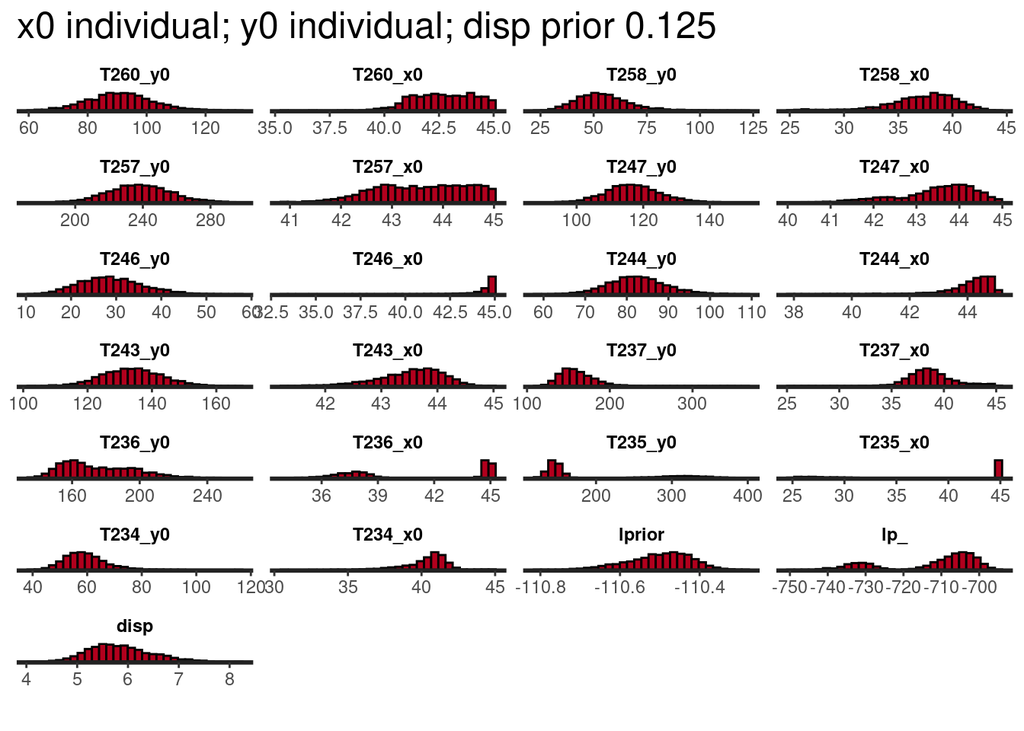

```
##  Family: nbinom_type1
##   Links: mu = identity; disp = identity
## Formula: y ~ two_piece(x, x0, y0)
##          x0 ~ 0 + male
##          y0 ~ 0 + male
##    Data: data (Number of observations: 107)
##   Draws: 4 chains, each with iter = 6000; warmup = 3000; thin = 4;
##          total post-warmup draws = 3000
##
## Population-Level Effects:
##             Estimate Est.Error l-95% CI u-95% CI Rhat Bulk_ESS Tail_ESS
## x0_maleT234    40.33      1.47    36.69    42.34 1.00     2530     1630
## x0_maleT235    31.73      7.75    25.13    44.99 1.53        7       31
## x0_maleT236    41.16      3.74    35.84    44.99 1.73        6      158
## x0_maleT237    38.68      2.35    34.55    44.00 1.00     2237     1848
## x0_maleT243    43.56      0.59    42.11    44.46 1.00     2878     2812
## x0_maleT244    44.13      0.82    41.97    44.97 1.00     2664     2722
## x0_maleT246    44.43      0.96    41.71    44.99 1.00     2579     2831
## x0_maleT247    43.53      0.87    41.47    44.76 1.00     2845     2762
## x0_maleT257    43.55      0.89    41.78    44.94 1.00     2705     2659
## x0_maleT258    37.18      3.19    29.06    42.11 1.00     2737     2018
## x0_maleT260    42.70      1.40    39.97    44.88 1.00     2739     2579
## y0_maleT234    59.55      7.48    46.87    76.70 1.00     2710     2476
## y0_maleT235   271.83     77.58   134.13   368.82 1.53        7       31
## y0_maleT236   176.06     21.46   144.74   222.19 1.59        7      155
## y0_maleT237   161.14     23.83   127.11   212.65 1.00     2657     2325
## y0_maleT243   133.81      9.40   116.31   152.74 1.00     2841     2904
## y0_maleT244    83.01      6.76    70.88    96.93 1.01     2925     2952
## y0_maleT246    28.83      6.89    16.09    43.40 1.00     2854     2401
## y0_maleT247   117.24      8.25   101.89   134.11 1.00     2772     2837
## y0_maleT257   238.76     18.01   204.31   274.07 1.00     3079     2796
## y0_maleT258    54.91     12.70    34.70    83.78 1.00     2553     2184
## y0_maleT260    91.42     11.06    71.05   114.26 1.00     2841     2834
##
## Family Specific Parameters:
##      Estimate Est.Error l-95% CI u-95% CI Rhat Bulk_ESS Tail_ESS
## disp     6.15      0.61     4.99     7.29 1.28       11       38
##
## Draws were sampled using sampling(NUTS). For each parameter, Bulk_ESS
## and Tail_ESS are effective sample size measures, and Rhat is the potential
## scale reduction factor on split chains (at convergence, Rhat = 1).
```

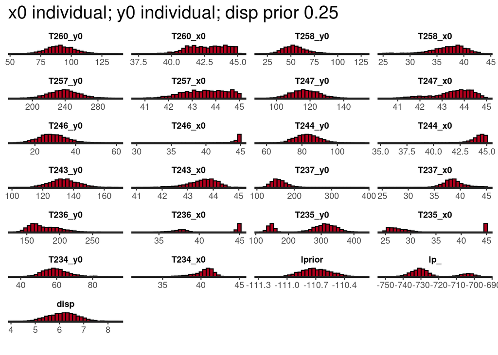

```r
          ##
          vars_fit <- names(fit_stan_rename) %>% na.omit(.) %>% sort(., decreasing = TRUE)
          ncol <- 4
          hist <-  stan_hist(fit_stan_rename,
                             pars = vars_fit,
                             bins = 30,
                             ncol = ncol) +
            ggtitle(desc_short)
          print(hist)
          filename <- paste0("histogram_", filename_desc, ".pdf")
          ggsave(filename = filename, path = file.path(output_dir, "figures"), dpi=300)
        }
         #end else for fitting
      }
    }
  }
}
```

```r
print(outfile_tbl)
```

```
## [1] "output/render/fit_tbl_2023-03-27.Rda"
```

```r
if(save_fits) save(fit_tbl, file = outfile_tbl)
```

## Exit rendering

```r
knitr::knit_exit()
```